# Additional Material: Random Forest Regression

Inayatus

April 15, 2021

# 1 [Additional Material] Random Forest Regression

Random Forest adalah salah satu jenis Ensemble Method. Random Forest melakukan prediksi dengan membuat banyak Decision Tree. Masing-masing Decision Tree memiliki karakteristik masing-masing dan tidak saling berhubungan satu sama lain. Random Forest kemudian melakukan prediksi untuk masing-masing decision tree, kemudian dari sekian banyak hasil prediksi tersebut dilakukan voting. Kelas dengan jumlah terbanyak akan menjadi hasil prediksi final. Random Forest memanfaatkan konsep bernama Bagging: Bootstrap and Aggregation. Berikut adalah proses yang terjadi:

1. Membuat data dengan random sampling dari data yang ada dan mengizinkan adanya duplikat (Bootstrap sampling)
2. Membuat decision tree dari masing-masing data hasil bootstrap sampling, digunakan prediktor sebanyak mtry yang juga dipilih secara random
3. Melakukan prediksi data baru untuk setiap decision tree
4. Melakukan majority voting untuk menentukan hasil prediksi final (Aggregation)

Kelebihan:

- Mereduksi bias sekaligus variance dari decision tree
- Robust untuk prediksi
- Automatic Feature Selection: pemilihan prediktor secara otomatis & random pada pembuatan decision tree
- Out-of-Bag error untuk pengganti evaluasi model ke data test (dibahas selanjutnya)

## 1.1 Workflow Analysis

1. Read data

```r
insurance <- read.csv("data_input/insurance.csv")
head(insurance)
```

|  | age | sex | bmi | children | smoker | region | charges |
| --- | --- | --- | --- | --- | --- | --- | --- |
| 1 | 19 | female | 27.900 | 0 | yes | southwest | 16884.924 |
| 2 | 18 | male | 33.770 | 1 | no | southeast | 1725.552 |
| 3 | 28 | male | 33.000 | 3 | no | southeast | 4449.462 |
| 4 | 33 | male | 22.705 | 0 | no | northwest | 21984.471 |
| 5 | 32 | male | 28.880 | 0 | no | northwest | 3866.855 |
| 6 | 31 | female | 25.740 | 0 | no | southeast | 3756.622 |

2. Pre-processing

```r
# insurance <- insurance %>%
#   mutate_if(is.character, as.factor)
```

3. Penentuan target variabel dan prediktor

Target variabel : charges Prediktor variabel : semua selain charges

[figure not shown]

```r
library(GGally)
ggpairs(insurance)
```

4. Splitting data menjadi data train dan test

Proporsi data train dan test biasanya 80%:20% atau 90%:10%.

```r
set.seed(100)
intrain <- sample(nrow(insurance), nrow(insurance)*0.8)
insurance_train <- insurance[intrain,]
insurance_test <- insurance[-intrain,]
```

5. Model fitting

```r
library(caret)
set.seed(100)
control <- trainControl(method = "cv", number = 3)
# pembuatan model random forest
model_insurance_rf <- train(charges~., data = insurance_train, method = "rf", trControl = control)
model_insurance_rf
```

```
#> Random Forest
#>
#> 1070 samples
#>    6 predictor
#>
#> No pre-processing
#> Resampling: Cross-Validated (3 fold)
#> Summary of sample sizes: 713, 714, 713
#> Resampling results across tuning parameters:
#>
#>   mtry  RMSE      Rsquared   MAE
#>   2     5463.694  0.8230907  3779.538
#>   5     4910.059  0.8297251  2809.742
#>   8     5063.528  0.8203075  2897.312
#>
#> RMSE was used to select the optimal model using the smallest value.
#> The final value used for the model was mtry = 5.
```

```r
set.seed(100)
control <- trainControl(method = "cv", number = 3)
# pembuatan model random forest
model_insurance_lm <- train(charges~., data = insurance_train, method = "lm", trControl = control)
model_insurance_lm
```

```
#> Linear Regression
#>
#> 1070 samples
#>    6 predictor
#>
#> No pre-processing
#> Resampling: Cross-Validated (3 fold)
#> Summary of sample sizes: 713, 714, 713
#> Resampling results:
#>
#>   RMSE    Rsquared   MAE
#>   6154.5  0.7340022  4251.545
#>
#> Tuning parameter 'intercept' was held constant at a value of TRUE
```

6. Model evaluation dari out of bag error

```r
library(randomForest)
model_insurance_rf$finalModel
```

```
#>
#> Call:
#>  randomForest(x = x, y = y, mtry = param$mtry)
#>                Type of random forest: regression
#>                      Number of trees: 500
#> No. of variables tried at each split: 5
#>
#>           Mean of squared residuals: 23243057
#>                     % Var explained: 83.63
```

7. Prediksi menggunaka data test

```r
pred_rf <- predict(model_insurance_rf, insurance_test)
pred_lm <- predict(model_insurance_lm, insurance_test)
```

8. Model evaluation berdasarkan data test

```r
library(MLmetrics)
MLmetrics::MAE(y_pred = pred_rf, y_true = insurance_test$charges)
```

```
#> [1] 2516.58
```

```r
MLmetrics::MAE(y_pred = pred_lm, y_true = insurance_test$charges)
```

```
#> [1] 4005.524
```

Cek error berdasarkan data train

```r
pred_train_rf <- predict(model_insurance_rf, insurance_train)
pred_train_lm <- predict(model_insurance_lm, insurance_train)
MLmetrics::MAE(y_pred = pred_train_rf, y_true = insurance_train$charges)
```

```
#> [1] 1427.308
```

```r
MLmetrics::MAE(y_pred = pred_train_lm, y_true = insurance_train$charges)
```

```
#> [1] 4227.363
```

Tujuan membandingkan hasil prediksi pada data train dengan hasil prediksi pada data test adalah untuk mengetahui kemampuan model apakah sudah sama baiknya jika digunakan dalam melakukan prediksi data baru.

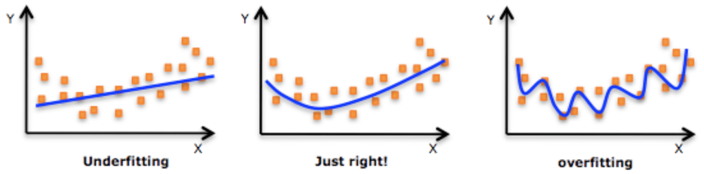

Perhatikan 3 kondisi di atas:

- model bagian kiri yang terlalu **sederhana** memiliki **bias tinggi** dan **variance rendah** sehingga hasil prediksinya tidak terlalu tepat (**Underfitting**). Contoh model dengan karakteristik ini adalah model linear regression.
- model bagian kanan yang terlalu **kompleks** memiliki **variance tinggi** dan **bias rendah** sehingga prediksi di data trainnya amat tepat, namun performanya buruk dalam memprediksi data test (**Overfitting**). Contoh model dengan karakteristik ini adalah decision tree.
- kondisi yang kita inginkan adalah model di bagian tengah: yang memiliki **bias** dan **variance** yang saling berimbang. Salah satu tujuan dari model tuning adalah mendapatkan bias-variance trade-off yang optimal ini, sehingga didapatkan model seperti di bagian tengah (“Just Right”).

```r
# model random forest
MAPE(y_pred = pred_train_rf, y_true = insurance_train$charges)*100
```

```
#> [1] 17.77554
```

```r
MAPE(y_pred = pred_rf, y_true = insurance_test$charges)*100
```

```
#> [1] 33.17804
```

```r
#model linear regression
MAPE(y_pred = pred_train_lm, y_true = insurance_train$charges)*100
```

```
#> [1] 42.24497
```

```r
MAPE(y_pred = pred_lm, y_true = insurance_test$charges)*100
```

```
#> [1] 40.58082
```